# DSA1101 Topic 5: Decision Trees

Dawn Cheung

2024-02-24

## Bank Sample Dataset

```r
library(tidyverse)
library(class)
library(rpart)
```

```r
library(rpart.plot) #remember its a diff package as rpart!!
bankdata = read.csv("~/Github/DSA1101 Slayers/datasets/bank-sample.csv")
attach(bankdata)

#response variable: subscribed (yes/no)
#we have 16 features => not using all (we will use 8)

fit <- rpart(subscribed ~ job + marital + education + default + housing + loan + contact + poutcome,
             method = "class", #tells R to return the category of response (yes or no)
             data = bankdata,
             control = rpart.control(minsplit = 1), #tells R how to split the node; minsplit = 1 means a branch is created when there is at least 1 observation in that branch => tells R how big we want the tree to be
             parms = list(split = "information")) # what criteria to use to choose the root node & internal nodes; either info gained or gini index; default val is gini

summary(fit)
```

```
## Call:
## rpart(formula = subscribed ~ job + marital + education + default +
##     housing + loan + contact + poutcome, data = bankdata, method = "class",
##     parms = list(split = "information"), control = rpart.control(minsplit = 1))
##   n= 2000
##
##           CP nsplit rel error    xerror       xstd
## 1 0.02843602      0 1.0000000 1.0000000 0.06511019
## 2 0.01658768      1 0.9715640 1.0236967 0.06578500
## 3 0.01000000      3 0.9383886 0.9810427 0.06456213
##
## Variable importance
##  poutcome education       job
##        80        11         9
##
## Node number 1: 2000 observations,    complexity param=0.02843602
##   predicted class=no   expected loss=0.1055  P(node) =1
##     class counts:  1789   211
##    probabilities: 0.895 0.105
##   left son=2 (1942 obs) right son=3 (58 obs)
##   Primary splits:
##       poutcome  splits as  LLRL,         improve=36.876590, (0 missing)
##       contact   splits as  RRL,          improve=25.971290, (0 missing)
##       housing   splits as  RL,           improve=18.328410, (0 missing)
##       job       splits as  LLLLLRLLRLRR, improve= 9.052902, (0 missing)
##       education splits as  LLRR,         improve= 3.328298, (0 missing)
##
## Node number 2: 1942 observations
##   predicted class=no   expected loss=0.09217302  P(node) =0.971
##     class counts:  1763   179
##    probabilities: 0.908 0.092
##
## Node number 3: 58 observations,    complexity param=0.01658768
##   predicted class=yes  expected loss=0.4482759  P(node) =0.029
##     class counts:    26    32
##    probabilities: 0.448 0.552
##   left son=6 (50 obs) right son=7 (8 obs)
##   Primary splits:
##       education splits as  RLLR,         improve=5.2742870, (0 missing)
##       job       splits as  LL--LLRLRLR-, improve=3.8479820, (0 missing)
```

[output cut: 15 more lines]

```
##
## Node number 7: 8 observations
##   predicted class=yes  expected loss=0  P(node) =0.004
##     class counts:     0     8
##    probabilities: 0.000 1.000
##
## Node number 12: 45 observations
##   predicted class=no   expected loss=0.4222222  P(node) =0.0225
##     class counts:    26    19
##    probabilities: 0.578 0.422
##
## Node number 13: 5 observations
##   predicted class=yes  expected loss=0  P(node) =0.0025
##     class counts:     0     5
##    probabilities: 0.000 1.000
```

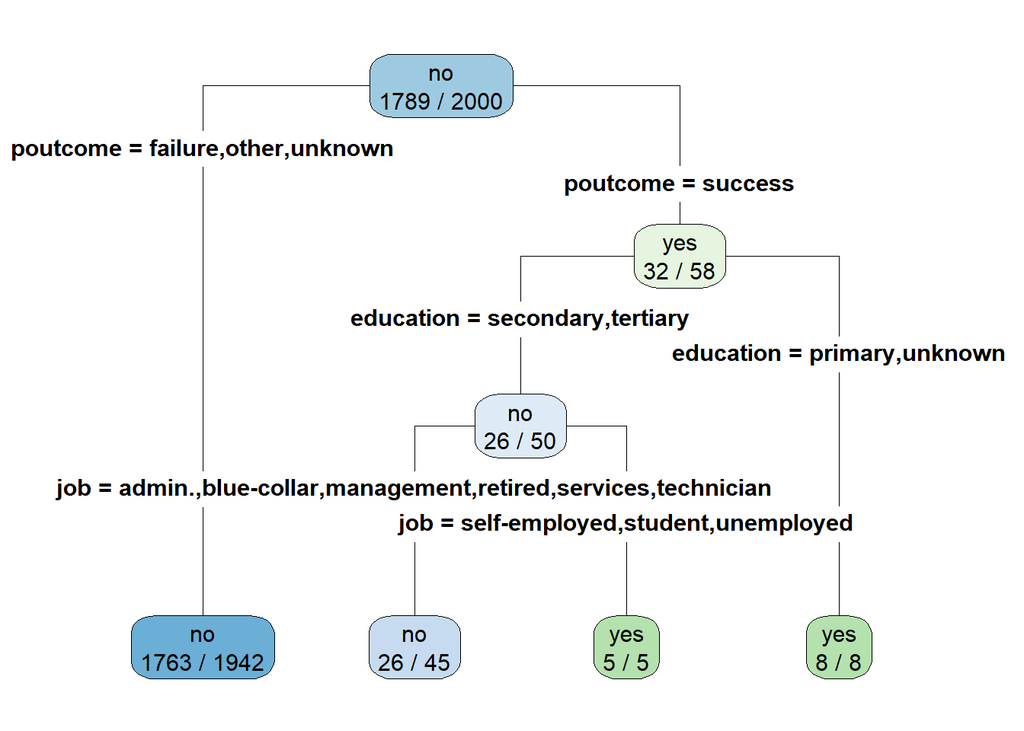

```r
#to fit the plotted tree:
rpart.plot(fit, type = 4, extra = 2, clip.right.labs = FALSE)
```

Ok notice the first node shown is a modal category of the response ie it starts with a no (which is the majority)

So not the root node (which needs to be an input vairable)

# Choosing the root node

## Why was poutcome selected as the decsion variable at the root node?

i.e. why was poutcome chosen by the algorithm to be the first split? finding the most useful feature in the dataset to add to the tree

Selecting the most informative attribute based on 2 basic measures: - Entropy: the impurity of an attribute - Information gain: the reduction in purity should a split be made there

## Purity

Its probability of the corresponding class - When only considering the particular response variable, ignoring all other attributes/features, then the probability of [the response variable being equal to something] is the purity - eg it is 89.45% pure on the class where [the response variable is equal to something], and the rest, 10.55% pure on the class [variable equals to smth else]

## Entropy

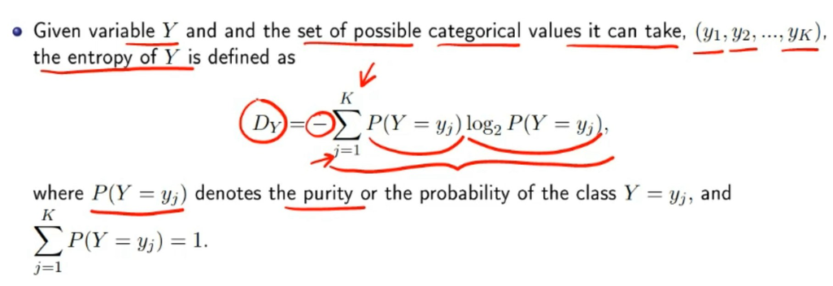

## Traversing down the tree, how are the subsequent decision variables at each node selected?

i.e. understanding how the algorithm decides what should be a branch and what should not be made into a branch

### Playing with maxdepth, minsplit, cp (complexity parameter) in control = rpart.control()

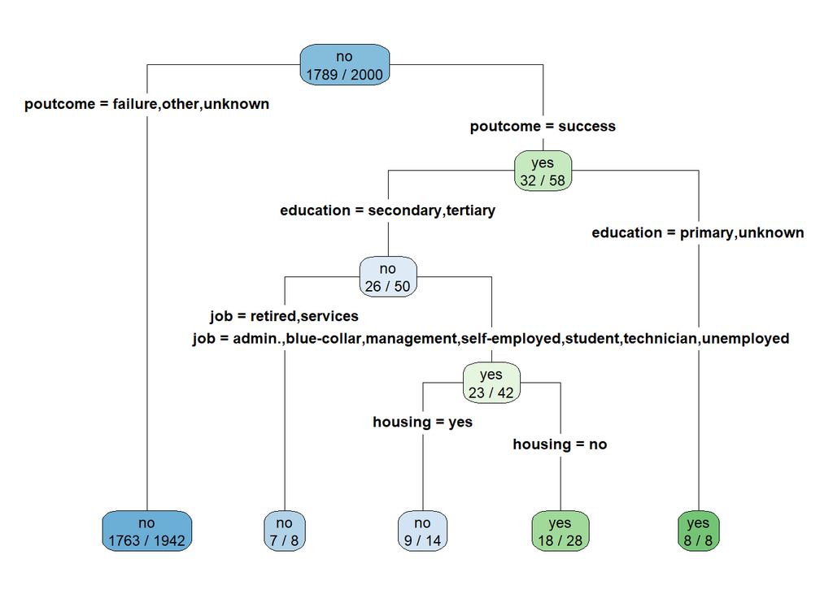

```r
#maxdepth = 4:
fit <- rpart(subscribed ~ job + marital + education + default + housing + loan + contact + poutcome,
             method = "class", #tells R to return the category of response (yes or no)
             data = bankdata,
             control = rpart.control(maxdepth = 4), #tells R how to split the node; minsplit = 1 means a branch is created when there is at least 1 observation in that branch => tells R how big we want the tree to be
             parms = list(split = "information"))

rpart.plot(fit, type = 4, extra = 2, clip.right.labs = FALSE)
```

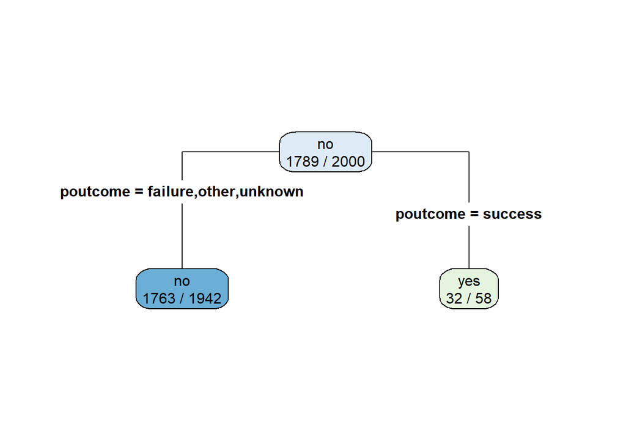

```r
#maxdepth = 1:
fit <- rpart(subscribed ~ job + marital + education + default + housing + loan + contact + poutcome,
             method = "class", #tells R to return the category of response (yes or no)
             data = bankdata,
             control = rpart.control(maxdepth = 1), #tells R how to split the node; minsplit = 1 means a branch is created when there is at least 1 observation in that branch => tells R how big we want the tree to be
             parms = list(split = "information"))

rpart.plot(fit, type = 4, extra = 2, clip.right.labs = FALSE)
```

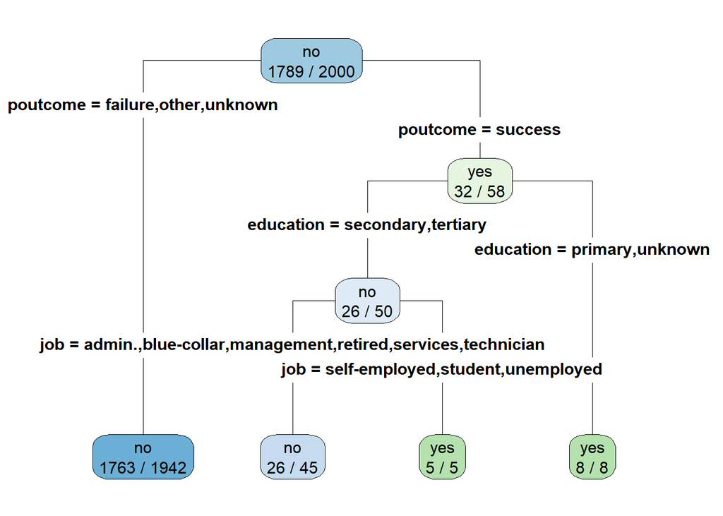

```r
#minsplit = 15:
fit <- rpart(subscribed ~ job + marital + education + default + housing + loan + contact + poutcome,
             method = "class", #tells R to return the category of response (yes or no)
             data = bankdata,
             control = rpart.control(minsplit = 15), #tells R how to split the node; minsplit = 1 means a branch is created when there is at least 1 observation in that branch => tells R how big we want the tree to be
             parms = list(split = "information")) # what criteria to use to choose the root node & internal nodes; either info gained or gini index; default val is gini

#to fit the plotted tree:
rpart.plot(fit, type = 4, extra = 2, clip.right.labs = FALSE)
```

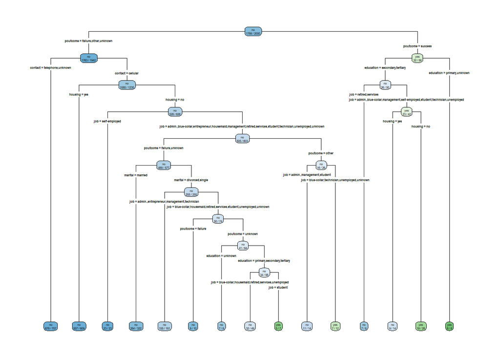

```r
#cp = 0.001
fit <- rpart(subscribed ~ job + marital + education + default + housing + loan + contact + poutcome,
             method = "class", #tells R to return the category of response (yes or no)
             data = bankdata,
             control = rpart.control(cp = 0.001), #tells R how to split the node; minsplit = 1 means a branch is created when there is at least 1 observation in that branch => tells R how big we want the tree to be
             parms = list(split = "information")) # what criteria to use to choose the root node & internal nodes; either info gained or gini index; default val is gini
rpart.plot(fit, type = 4, extra = 2, clip.right.labs = FALSE)
```

As maxdepth increases, tree becomes larger.

As minsplit increases, tree becomes smaller.

As cp decreases, tree becomes larger. [default is cp = 0.01]

### How to test which parameters are best? Just use for loops to try each parameter and attain accuracy lol

### Playing with varlen, faclen, clip.right.labs, type in rpart.plot()

- varlen = variable length
  - 0: full name will be written
- faclen = factor length
  - 0: full name will be written
- clip.right.labs literally means the name of the variable wont be repeated on the right branch
  - TRUE or FALSE

MEANING OF THE TREE WILL REMAIN THE SAME

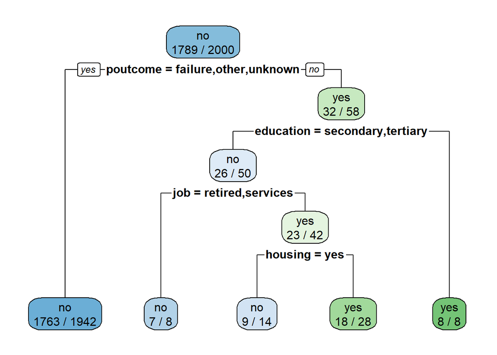

```r
fit <- rpart(subscribed ~ job + marital + education + default + housing + loan + contact + poutcome,
             method = "class", #tells R to return the category of response (yes or no)
             data = bankdata,
             control = rpart.control(maxdepth = 4), #tells R how to split the node; minsplit = 1 means a branch is created when there is at least 1 observation in that branch => tells R how big we want the tree to be
             parms = list(split = "information"))

#type = 2:
rpart.plot(fit, type = 2, extra = 2, clip.right.labs = FALSE)
```

### Analysis of Fitted Tree

modal catagory => the major/majority catagory

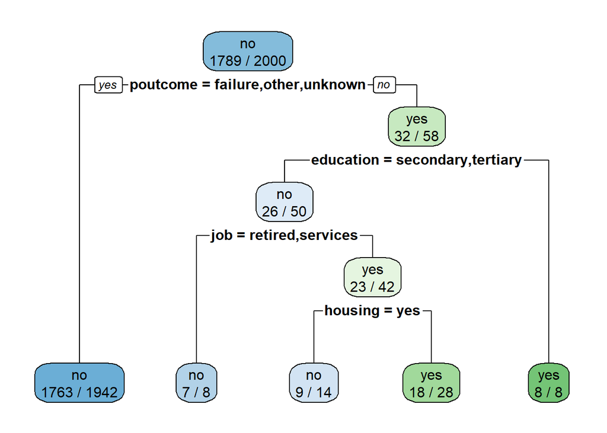

```r
fit <- rpart(subscribed ~ job + marital + education + default + housing + loan + contact + poutcome,
             method = "class", #tells R to return the category of response (yes or no)
             data = bankdata,
             control = rpart.control(maxdepth = 4), #tells R how to split the node; minsplit = 1 means a branch is created when there is at least 1 observation in that branch => tells R how big we want the tree to be
             parms = list(split = "information"))

#type = 2:
rpart.plot(fit, type = 2, extra = 2, clip.right.labs = FALSE)
```

how model decides how to structure the tree: by splitting at this depth, it reduces the entropy the most

## DTdata.csv [play_decsion]

```r
library(rpart)
library(rpart.plot) #remember its a diff package as rpart!!
play_decsion = read.csv("~/Github/DSA1101 Slayers/datasets/DTdata.csv")
attach(play_decsion)

newdata = data.frame(Outlook = "rainy", Temperature = "mild", Humidity = "")
```